# Final_Report_Part2

## Methodology

> This part provides an overview of the approach used in this project to explore and analyse the data.

### Deal with missing values

Income data in year 1990, 2000 and 2012 has the following number of empty values: 2487, 5112 and 5662.

Remember in the **Data Summary** part, missing values were handeled using the **na.rm = TRUE** command. To further deal with missing values in income variables, two basic steps are used here.

- Estimate the income value in year 2012 according to `estimated.low.income.2012` and `estimated.high.income.2012` variables in the database. The mean value of these variables are used to simulate the missing `income.2012` value.
- After the estimation, only data with non-NA income values in all three years are kept and any data with any one of the income value missing is removed.The code below shows that the `cleaned.nlsy` data frame only keeps rows with all three income values not null.

The code for these two steps is as follows:

```r
for(i in 1:12686){
  if(is.na(nlsy[i, "income.2012"]) &
     !is.na(nlsy[i, "estimated.low.income.2012"]) &
     !is.na(nlsy[i, "estimated.high.income.2012"])) {
    nlsy[i, "income.2012"] =
      (nlsy[i, "estimated.low.income.2012"] + nlsy[i, "estimated.high.income.2012"]) / 2
  }
}

# Remove all entries that miss any income
cleaned.nlsy = nlsy[which(!is.na(nlsy$income.1990)
                          & !is.na(nlsy$income.2000)
                          & !is.na(nlsy$income.2012)), ]
```

#### further cleaning

The main analysis of this project is focusing on data with income values that are neither top-coded nor outliers (zero or negative), and only some very relative variables are selected for analysis in each three years. Therefore, further cleaning of `cleaed.nlsy` is done by selecting several columns and applying filters to remove top-coded values. Take income in 1990 as an example:

```r
clean.nlsy.income1990.1 = select(cleaned.nlsy,
                                 income.1990,
                                 gender,
                                 race,
                                 age.start.alcohol.1984,
                                 womens.roles.q1,
                                 womens.roles.q2,
                                 family.size.1979
                                 ) %>%
  filter(income.1990 > 0,
         income.1990 < max(cleaned.nlsy$income.1990))
```

Here `max(cleaned.nlsy$income.1990)` refers to the top-coded value of the `income.1990`, i.e. the top 2% of the income values.

### Top coded value

Top-coded income group and the unemployed group whose incomes are no more than zero have been considered separately in the logistic regression. This means that a normalised data set is obtained in terms of incomes in each of the years to perform logistic regression on.

Each income data is segregated into 3 different sections based on income values:

- Respondents with top 2% income
- Respondents who are unemployed or 0 income
- Respondents with income range in between

The following code filters out the top 2% and unemployed respondents to work on a much more normalized data frame:

```r
clean.nlsy.income1990.1 = select(cleaned.nlsy,
                                 income.1990,
                                 gender,
                                 race,
                                 age.start.alcohol.1984,
                                 womens.roles.q1,
                                 womens.roles.q2,
                                 family.size.1979
                                 ) %>%
  filter(income.1990 > 0,
         income.1990 < max(cleaned.nlsy$income.1990))

ggplot(clean.nlsy.income1990.1, aes(x=income.1990))+geom_histogram(binwidth = 250)
```

[output not shown]

Another approach used to deal with top-coded values is to create another column called high.income which acts as a filter for top-coded data.

The use of such an approach is highlighted below:

```r
clean.nlsy.income1990.2 = select(cleaned.nlsy,
                                 income.1990,
                                 gender,
                                 race,
                                 age.start.alcohol.1984,
                                 womens.roles.q1,
                                 womens.roles.q2,
                                 family.size.1979
                                 ) %>%
  filter(income.1990>0)

for(i in 1:4999) {
  if(clean.nlsy.income1990.2[i, "income.1990"] == max(cleaned.nlsy$income.1990)) {
    clean.nlsy.income1990.2[i, "high.income"] = TRUE
  } else{
    clean.nlsy.income1990.2[i, "high.income"] = FALSE
  }
}
```

### Potentially interesting trends

#### womens.roles.q1

The variable `womens.roles.q1` i.e. the response to the question “WOMAN’S PLACE IS IN THE HOME?” seems like a significant factor in affecting the income atleast for the year 1990, because people with such narrow-minded mentality are more like to show an income descrepancy between men and women.

| Response to the question | gender | Mean income | Standard deviation of income | Median of income |
| --- | --- | --- | --- | --- |
| Strongly disagree | Female | 13863.106 | 12982.219 | 12500 |
| Strongly disagree | Male | 21528.797 | 16811.411 | 19600 |
| Disagree | Female | 10685.972 | 10871.700 | 9000 |
| Disagree | Male | 20034.474 | 15760.788 | 18000 |
| Agree | Female | 8046.317 | 9280.847 | 5000 |
| Agree | Male | 18487.453 | 15111.703 | 16650 |
| Strongly agree | Female | 6774.775 | 9962.623 | 1500 |
| Strongly agree | Male | 16670.825 | 14348.270 | 15000 |
| NA | Female | 8851.087 | 8270.938 | 8100 |
| NA | Male | 15767.125 | 10373.784 | 15000 |

A clear trend is very difficult to spot here. Maybe a plot will help.

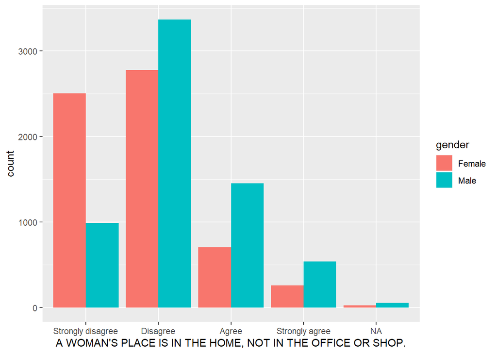

Women are less likely to agree than men on this topic, and most people irrespective of gender tend to disagree.

```
##     womens.roles.q1 gender income.1990
## 1 Strongly disagree Female   13863.106
## 2          Disagree Female   10685.972
## 3             Agree Female    8046.317
## 4    Strongly agree Female    6774.775
## 5 Strongly disagree   Male   21528.797
## 6          Disagree   Male   20034.474
## 7             Agree   Male   18487.453
## 8    Strongly agree   Male   16670.825
```

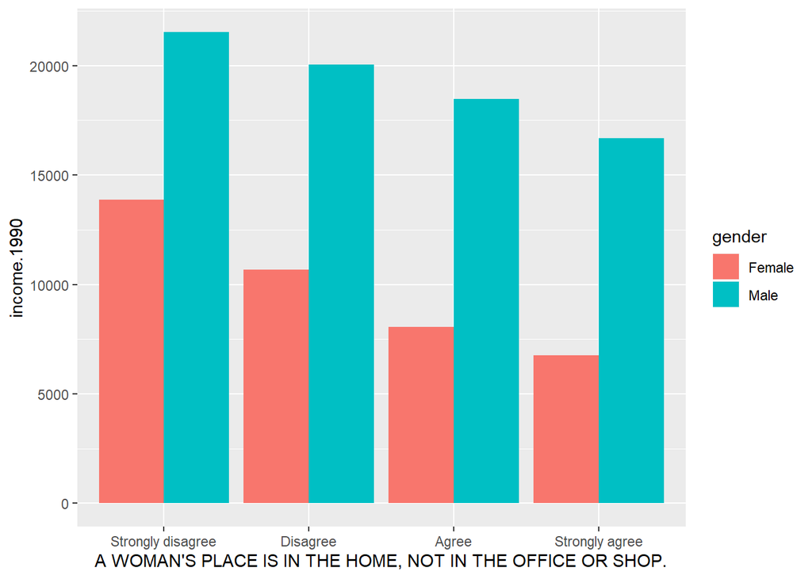

#### womens.roles.q3

Similar to the previous variable, the `womens.roles.q3` column i.e. the answer to the question “WORKING WIFE FEELS MORE USEFUL?” should indicate a postive mindset which can encourage gender equality. Here’s a detailed analysis of this variable and its relationship with gender and income:

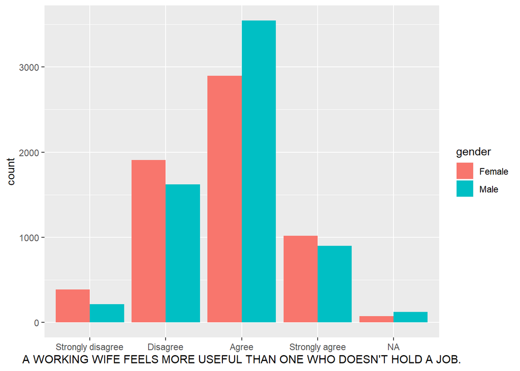

Most people seem to agree with this mentality with a large number of the people agreeing being male. Some women surprisingly disagreed which is why the numbers of people agreeing seems evenly distributed across both genders.

| Response to the question | gender | Mean income | Standard deviation of income | Median of income |
| --- | --- | --- | --- | --- |
| Strongly disagree | Female | 12481.10 | 13510.79 | 9000 |
| Strongly disagree | Male | 18373.53 | 14288.34 | 16000 |
| Disagree | Female | 11383.97 | 11950.01 | 9500 |
| Disagree | Male | 19769.37 | 15552.89 | 18000 |
| Agree | Female | 11139.25 | 11218.92 | 10000 |
| Agree | Male | 19582.57 | 15494.28 | 18000 |
| Strongly agree | Female | 11937.28 | 11901.35 | 10000 |
| Strongly agree | Male | 19867.98 | 17128.66 | 17000 |
| NA | Female | 13009.29 | 14169.74 | 10500 |
| NA | Male | 16476.47 | 13489.02 | 15000 |

This table again shows a big gap between male and female wages but the correlation with income disparity still is unclear. It might be more prominent in a plot:

```
##     womens.roles.q3 gender income.1990
## 1 Strongly disagree Female    12481.10
## 2          Disagree Female    11383.97
## 3             Agree Female    11139.25
## 4    Strongly agree Female    11937.28
## 5 Strongly disagree   Male    18373.53
## 6          Disagree   Male    19769.37
## 7             Agree   Male    19582.57
## 8    Strongly agree   Male    19867.98
```

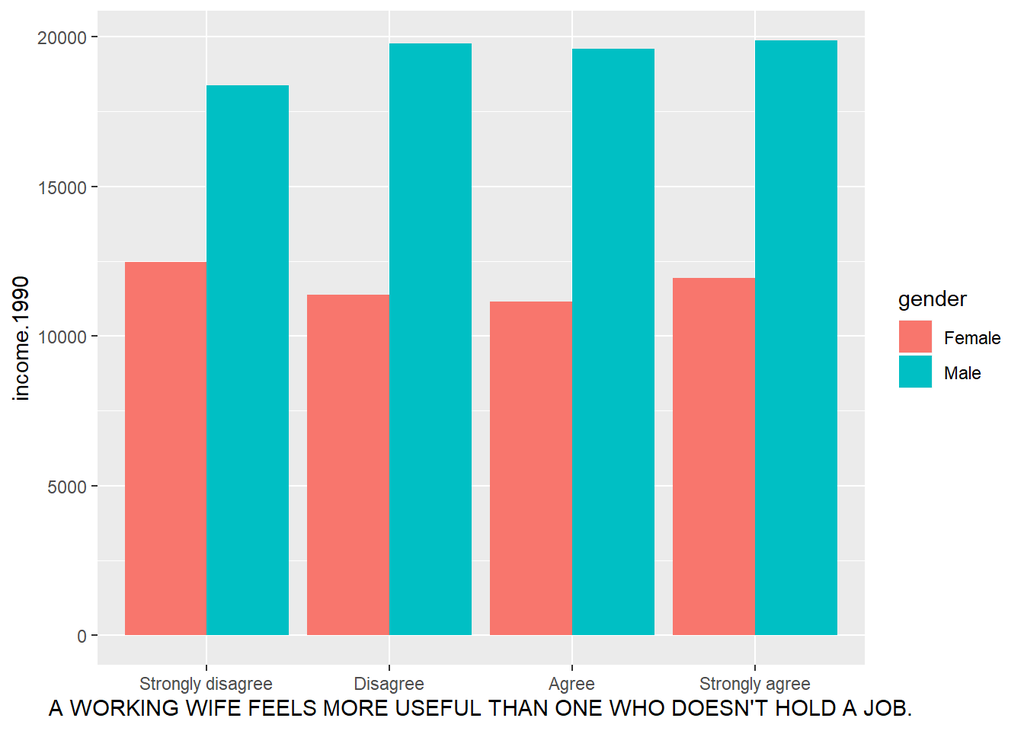

There seems to be no obvious relationship between this attitude and income disparity between genders even though it seemed like a significant variable.

### Investigated relationships

There are many variables associated with drug use in the nlsy dataset. We compared all of them with gender based income disparity.

#### age.start.drug.use.1984

The variable `age.start.drug.use.1984`(NO OF TIMES USED MARIJUANA IN LIFETIME) was one of them.

| gender | Number of times consumed marijuana (N) | Mean of N | Standard deviation of N | Median of N |
| --- | --- | --- | --- | --- |
| Female | 917 | 16.03817 | 2.445400 | 16 |
| Male | 1214 | 15.45881 | 2.561919 | 16 |

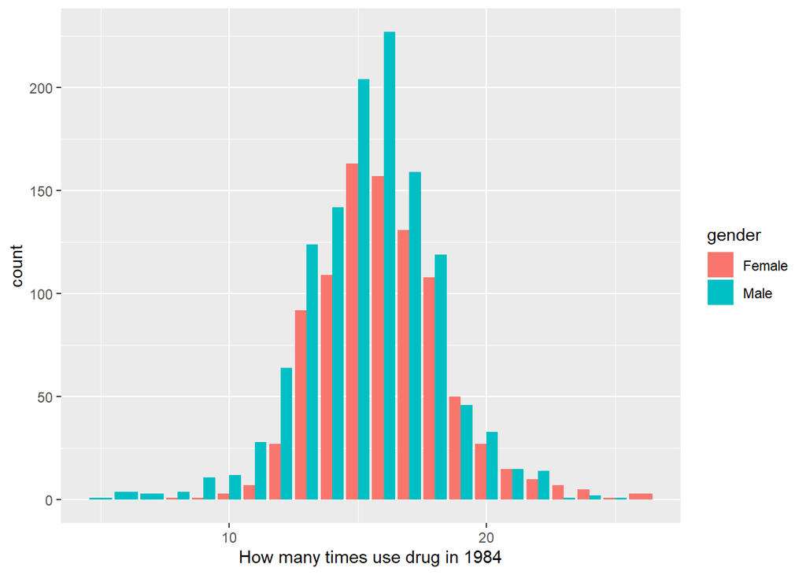

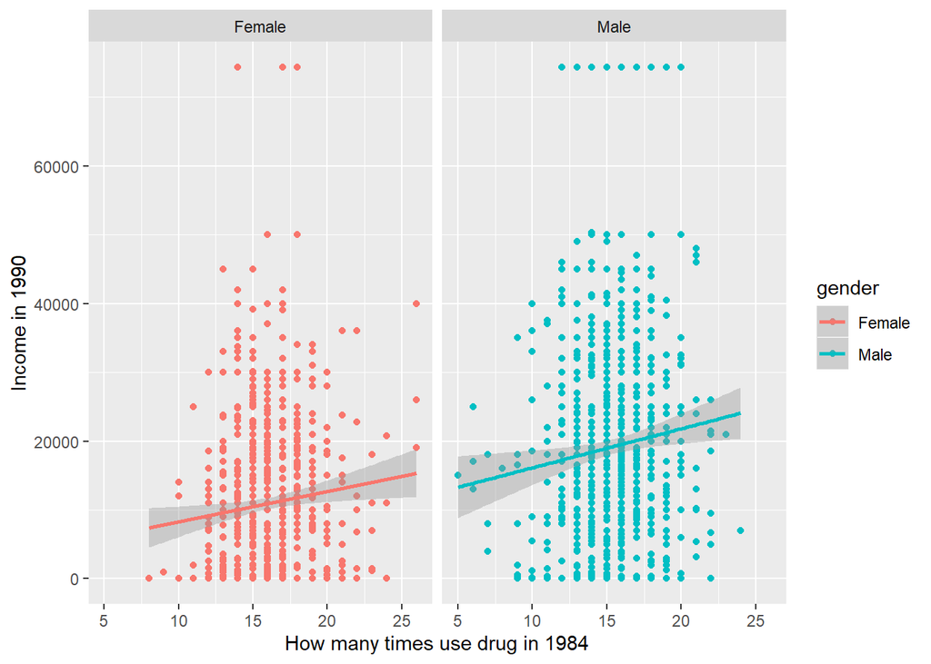

#### age.start.drug.use.1998

The `age.start.drug.use.1998` variable, gives the age of the respondent when he/she first used cocaine. This could be one of the factors behind the gender based disparity being created due to drug use patterns in the society.

| gender | Mean age of first use of cocaine A | Standard deviation of A | Median of family size |
| --- | --- | --- | --- |
| Female | 20.54178 | 5.535765 | 20 |
| Male | 20.68883 | 5.846254 | 20 |

It seems like female respondents started to use the drug a little bit earlier than males. But it doesn’t seem like a significant difference.

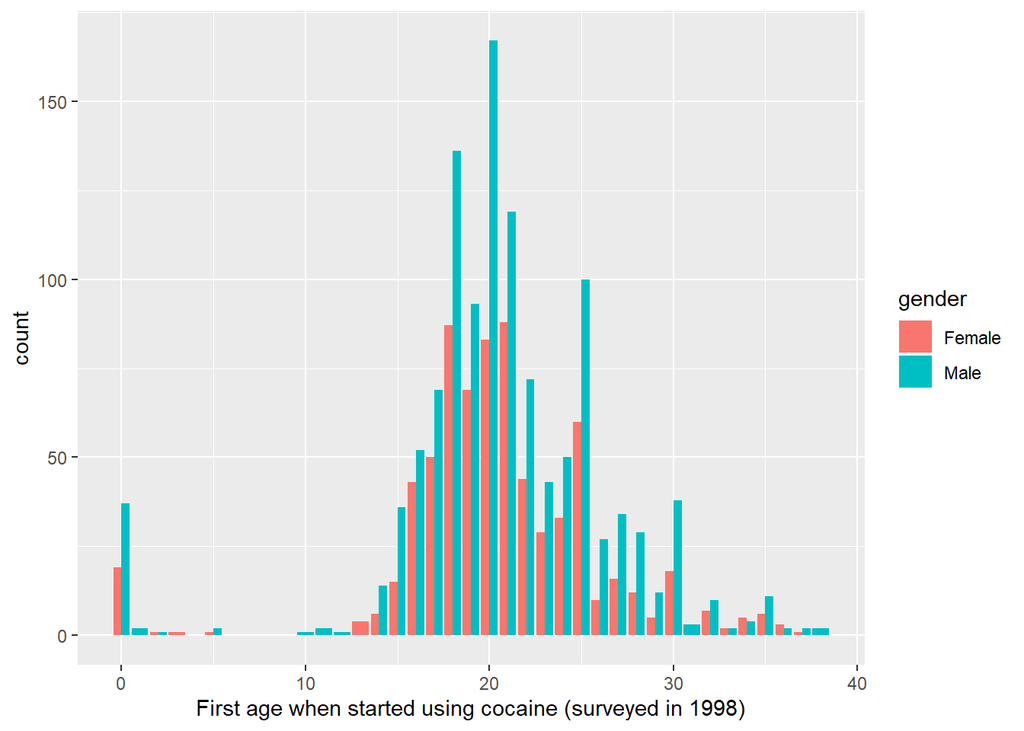

The people with zero values are the ones who did not use cocaine ever. It seems that a very small percentage of the suvery pool had never consumed cocaine in their life. This is a striking share of the respondents who have used cocaine. The number female respondents who have never consumed cocaine is less than male ones.

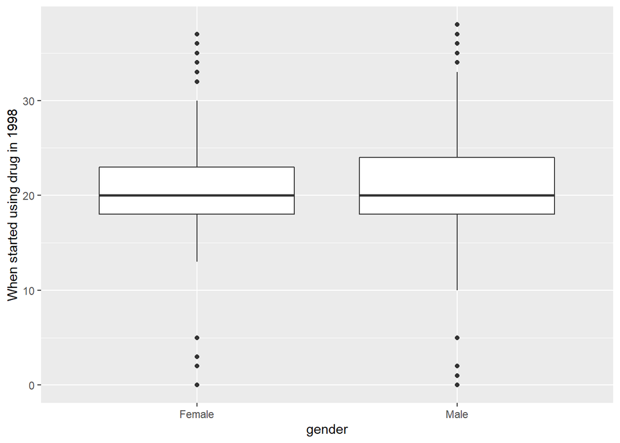

From the plot, it seems that the deviation for male respondents about the first time use of the drug is bigger than that of female respondents, also the average for females is lower. But lets compare these to income:

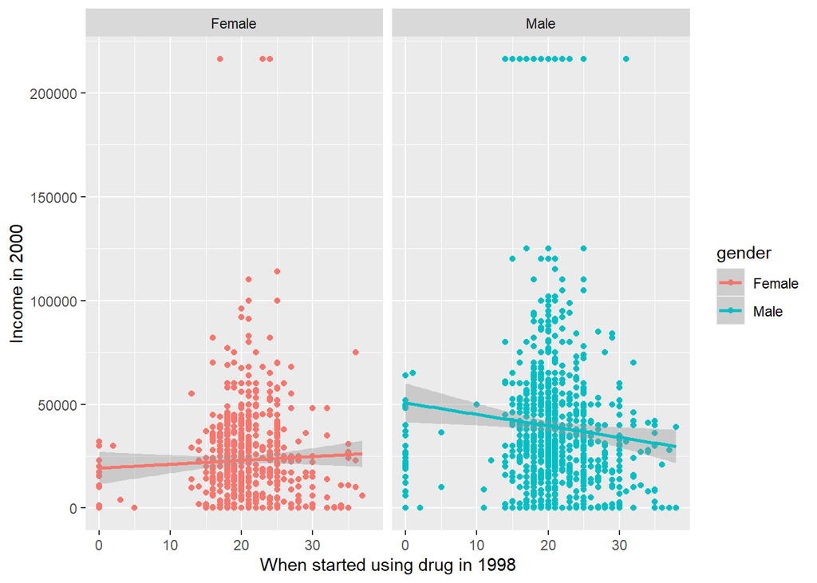

It seems that for female respondents, the later they start to use drug, the higher income they will have, while for males, the later they start to use the drug, the lower they will earn. But it does not seem to contribute to gender based income disparity the way it was thought to be possible.

### Deciding the final analysis

We will consider the values related to 1990 Income first:

#### 1. Income 1990

##### race

As discussed before, race shows clear disparity in income by itself. But combined with gender there needs to be significant difference to consider race as a factor for gender-based income disparity.

Since it has been discussed in the Data Summary, lets look at the other variables considered for the final analysis.

##### First age of alcohol consumption

This factor can have a big impact on an individuals life and highlights the types of influences a person has in his life. Turns out it gave significant results in terms of gender discrepancy and income.

```
##    Min. 1st Qu.  Median    Mean 3rd Qu.    Max.
##    1.00   16.00   17.00   17.01   18.00   25.00
```

| gender | Number of times consumed alcohol (N) | Mean of N | Standard deviation of N | Median of N |
| --- | --- | --- | --- | --- |
| Female | 4352 | 17.44761 | 2.040954 | 18 |
| Male | 5274 | 16.64088 | 2.159654 | 17 |

From the table, it is seen that more male respondents drink at a younger age than female ones. The average first age of alcohol consumption of female respondents is about one year greater than that of male. Women start to drink at about 17-18 years old while Male at about 16-17. The deviation in the data is nearly the same for both genders.

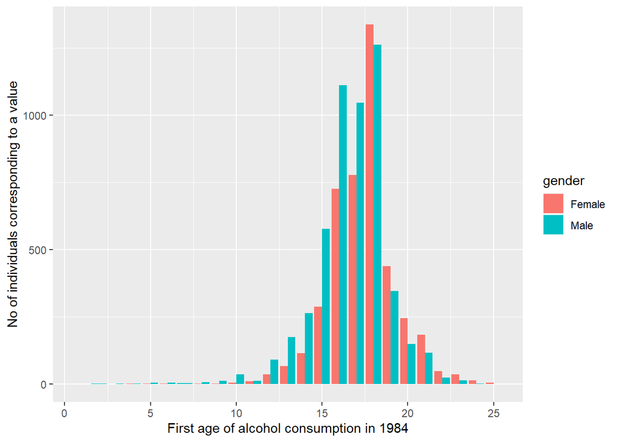

From the graph, it is clear that the distribution of first age of alcohol consumption all looks like normal distribution.

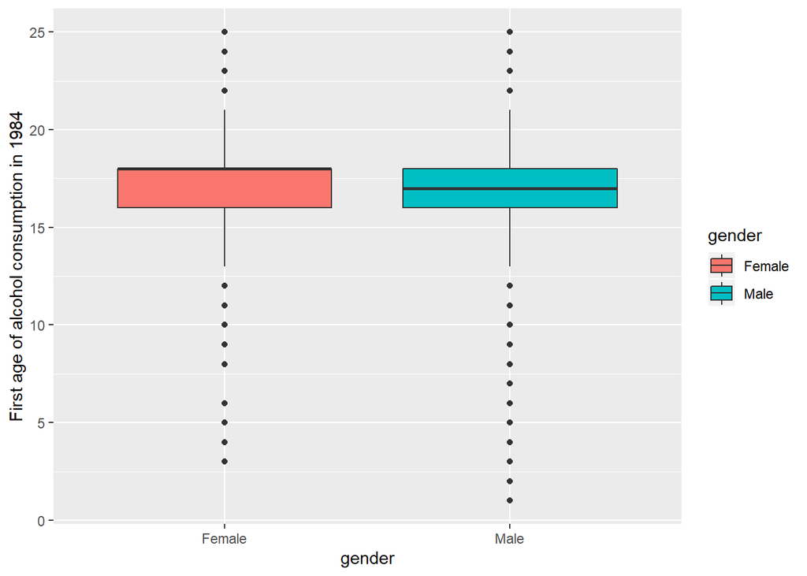

The boxplot shows that at least 20% female respondents started to drink at 18 years old, while the distribution of male respondents is more normal.

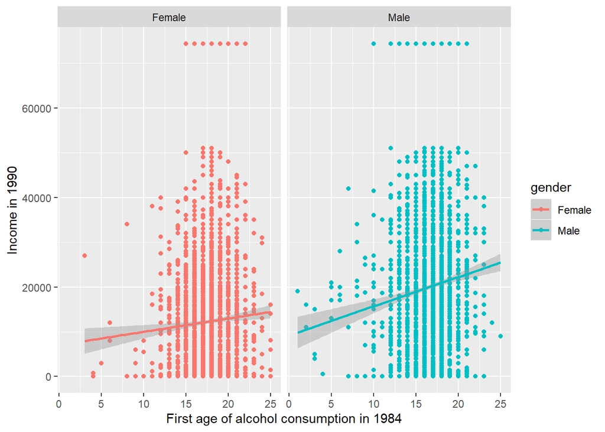

The graph shows that the later one comsumes alcohol, the higher income he or she will earn. This difference is more prominent in men than in women.

##### Family attitude

The significant variable chosen for this assessment was the response to the family attitude of “WIFE WITH FAMILY HAS NO TIME FOR OTHER” which was ‘womens.roles.q2’.

| Response to the question | gender | Mean of income | Standard deviation of income | Median of income |
| --- | --- | --- | --- | --- |
| Strongly disagree | Female | 13773.089 | 12681.264 | 13000.0 |
| Strongly disagree | Male | 21715.504 | 17920.606 | 19000.0 |
| Disagree | Female | 11793.922 | 11778.224 | 10000.0 |
| Disagree | Male | 20616.450 | 16076.489 | 18550.0 |
| Agree | Female | 9167.859 | 10659.935 | 6000.0 |
| Agree | Male | 17857.963 | 14502.170 | 16000.0 |
| Strongly agree | Female | 7374.768 | 8750.807 | 4000.0 |
| Strongly agree | Male | 17246.608 | 14657.339 | 15757.5 |
| NA | Female | 10335.600 | 12461.404 | 4250.0 |
| NA | Male | 16729.489 | 9670.052 | 16000.0 |

The income is greater for male respondents again, compared to female respondents. The people disagreeing with this narrow-minded attitude have a higher income compared to those agreeing with it.

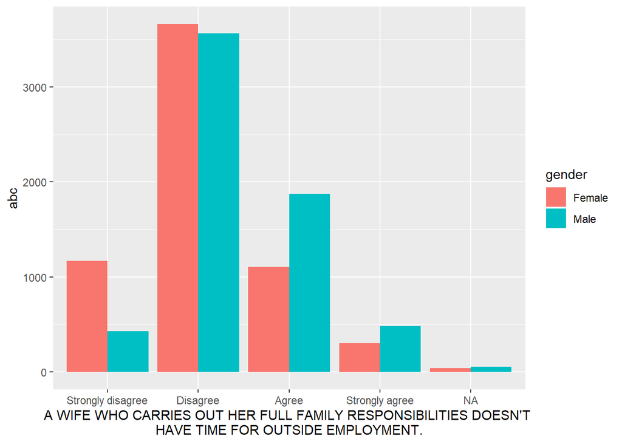

Irrespective of gender, most people disagree with this attitude. But women are in general more likely to disagree with this attitude.

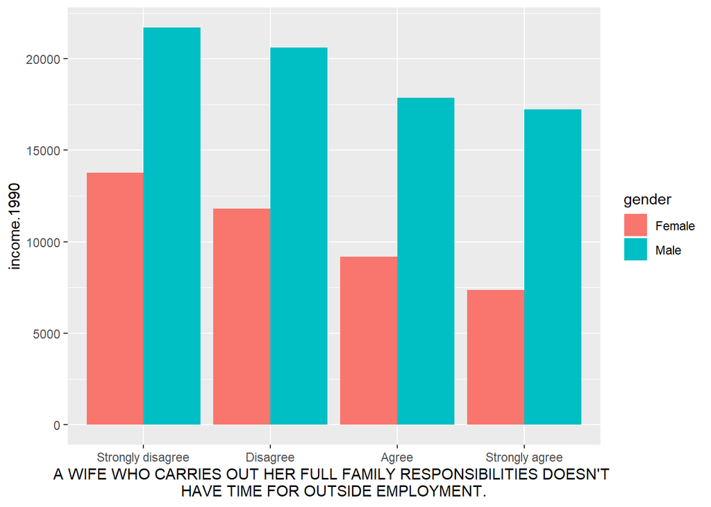

From the plot, it seems that the more people disagree, the more income they will earn. The trend for female respondents is more obvious than that for male.

##### Family Size in 1979

Similar to family attitudes, family size is a big part of an individual’s upbringing. The family size can be corelated to the income in 1990. People hailing for different family sizes have different upbringing which can be a significant contributor to income or even income disparity based on gender. Analysing this variable, it can be seen that:

| gender | Mean of family size | Standard deviation of family size | Median of family size |
| --- | --- | --- | --- |
| Female | 4.260544 | 2.305486 | 4 |
| Male | 4.275496 | 2.375945 | 4 |

This variable is strikingly similar for both genders. The mean, median and standard deviation all are almost the same for both.

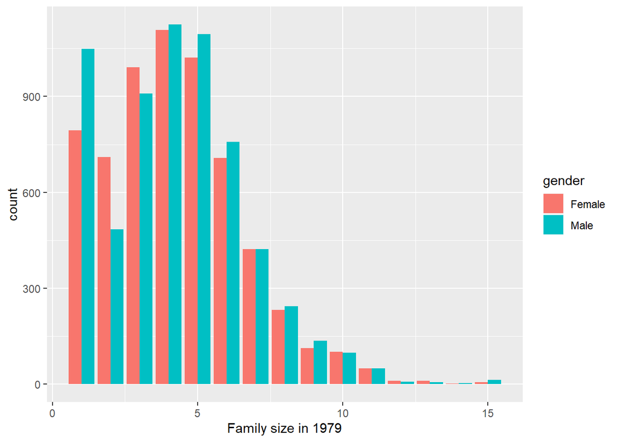

The graph also shows that the variable is similar for both male and female respondents.

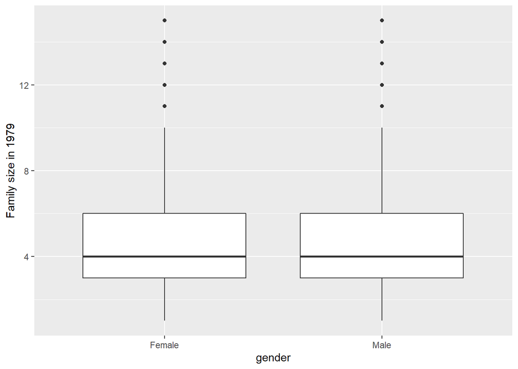

The boxplot confirms this trend and shows that even that quartile distribution for both genders is the same.

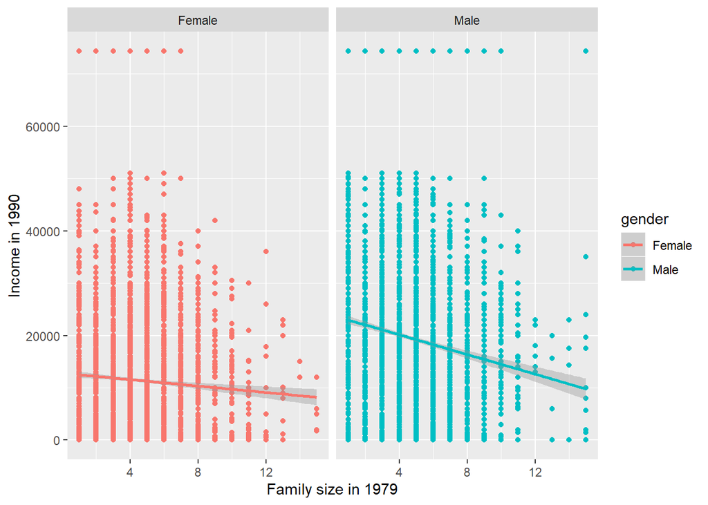

But despite the similarities, the income for male respondents is affected a lot more than that for female respondents for an increase the family size while growing up. This means that while growing up men are more susceptible to be affected by a large family size.

#### 2. Income in 2000

This income variable is tested for correaltion with many different variables. Here’s a boxplot of the income of both genders:

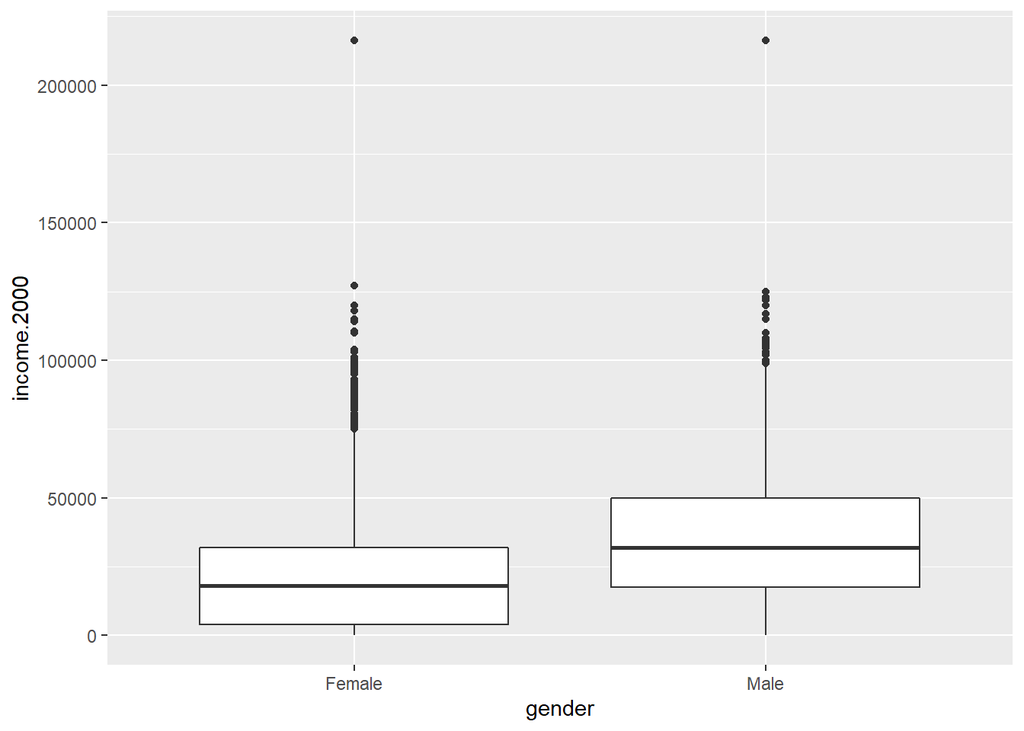

The gender-based income gap is striking, but we need to understand this cap and other factors potentially responsible for it.

##### Marital Status

The marriage status marital.status.2000 could shine some light on this income gap in 2000. Here’s a look at the marriage statistics for the year 2000:

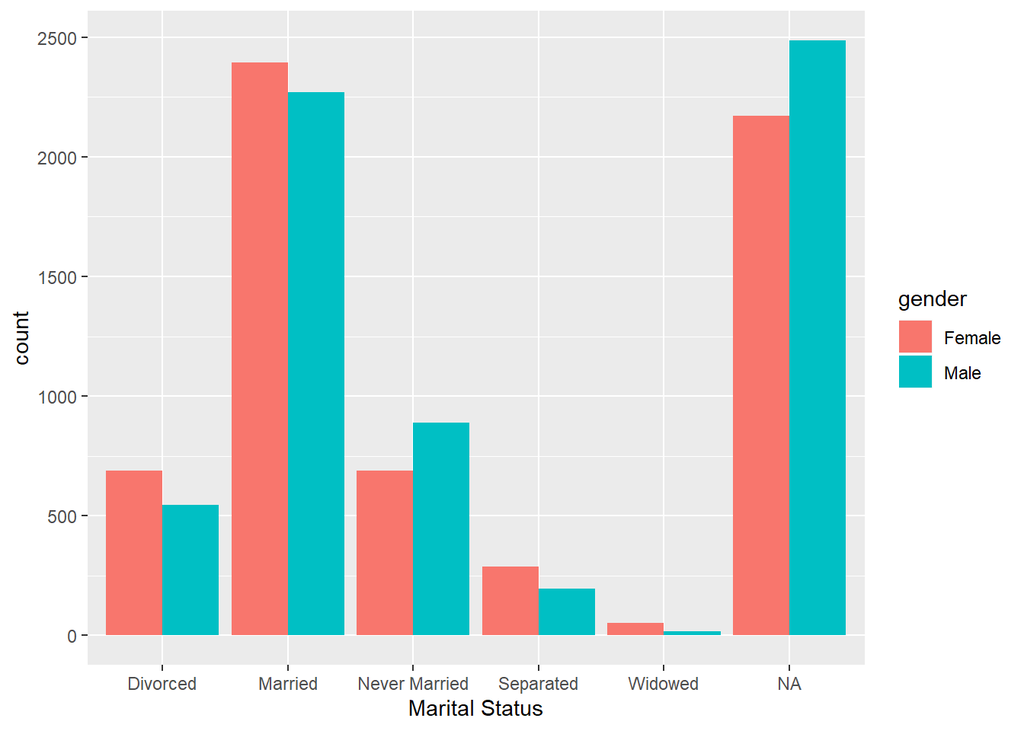

There are many married respondents and many respondents chose not to answer this question. The number widowed respondents is very low.

| Marital Status | gender | Income in 2000 |
| --- | --- | --- |
| Divorced | Female | 23822.46 |
| Married | Female | 22240.59 |
| Never Married | Female | 21469.85 |
| Separated | Female | 15222.84 |
| Widowed | Female | 17272.39 |
| Divorced | Male | 31665.38 |
| Married | Male | 48115.32 |
| Never Married | Male | 24918.22 |
| Separated | Male | 25591.27 |
| Widowed | Male | 41225.33 |

The salaries of men are again higher irrespective of marital status. There might be something more obvious seen through a graph:

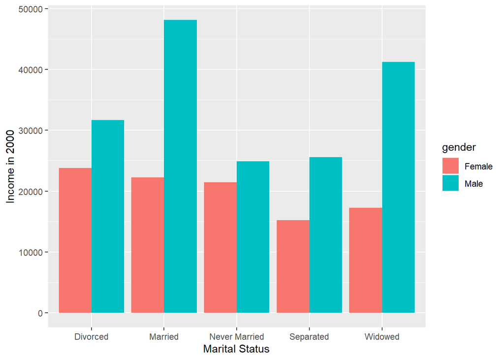

Married man have far more income than married women.This is also true for widowed men, although their numbers were not as high. The difference is less prominent amongsts those who have never been married.

##### race

It seems to be another key factor affecting the income gap in all three years. The gender distribution for the three races is given below:

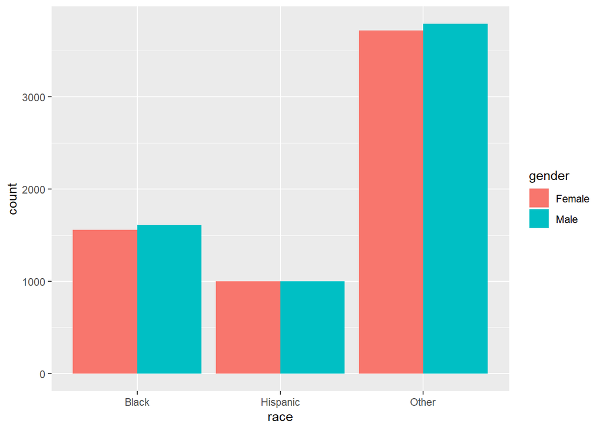

Most people belong to the ‘other’ race category. The number of men and women in all three races is almost equal.

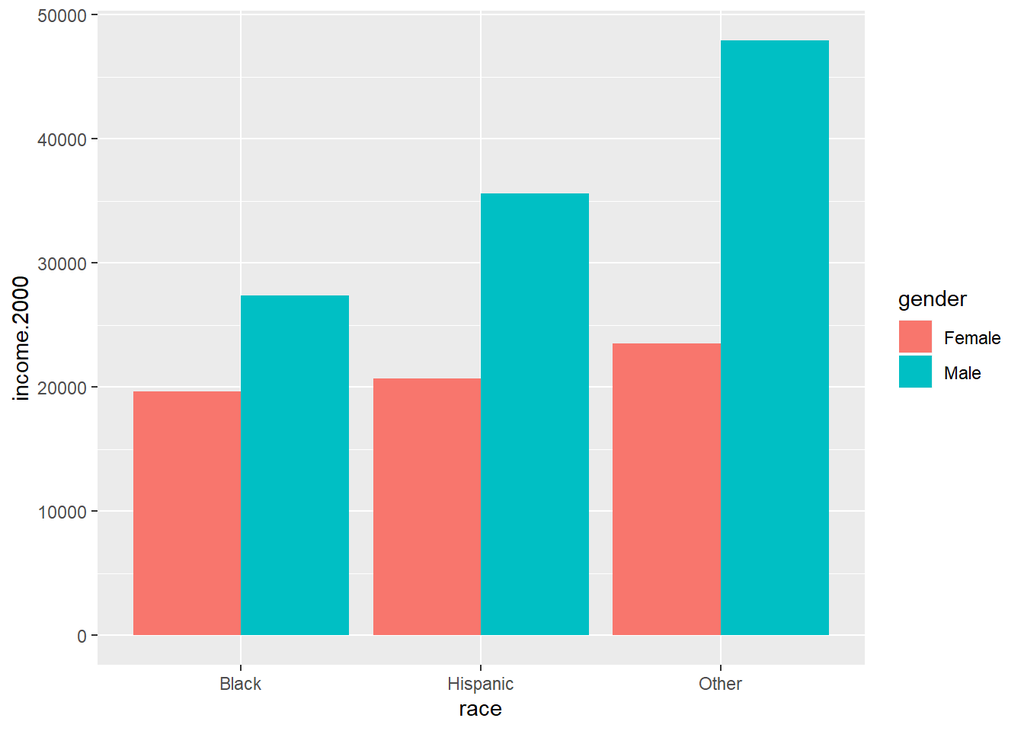

An income analysis makes it clear that the income gap between women across the three races is not very prominent. But it is a significant gap across all three races for men. The gender income disparity is most prominent amongst the ‘other’ race while it is least prominent in ‘black’ race.

##### industry

The industry of occupation (industry.2000) could be responsible for for the income gap. Lets have a look at the various industries:

| Industry | gender | Mean of income | Standard deviation of income | Median of income |
| --- | --- | --- | --- | --- |
| AGRICULTURE,FORESTRY AND FISHERIES | Female | 15988.1944 | 12370.145 | 13000.0 |
| AGRICULTURE,FORESTRY AND FISHERIES | Male | 26267.2895 | 31633.304 | 20000.0 |
| BUSINESS AND REPAIR SERVICES | Female | 28354.9123 | 32020.683 | 20000.0 |
| BUSINESS AND REPAIR SERVICES | Male | 44012.8619 | 49564.394 | 30000.0 |
| CONSTRUCTION | Female | 20380.3016 | 16517.260 | 20000.0 |
| CONSTRUCTION | Male | 36828.0291 | 33105.968 | 30000.0 |
| ENTERTAINMENT AND RECREATION SERVICES | Female | 26724.9333 | 32829.228 | 16404.5 |
| ENTERTAINMENT AND RECREATION SERVICES | Male | 35940.3509 | 35311.304 | 28000.0 |
| FINANCE,INSURANCE AND REAL ESTATE | Female | 31940.0502 | 25691.735 | 30000.0 |
| FINANCE,INSURANCE AND REAL ESTATE | Male | 62522.0197 | 57662.192 | 45000.0 |
| MANUFACTURING | Female | 27301.9868 | 23341.769 | 23000.0 |
| MANUFACTURING | Male | 44912.2480 | 38841.502 | 35000.0 |
| MINING | Female | 23250.0000 | 17458.113 | 23000.0 |
| MINING | Male | 48851.7000 | 24885.716 | 47790.0 |
| OTHERS | Female | 34280.0000 | 52163.318 | 19000.0 |
| OTHERS | Male | 65183.3333 | 58198.748 | 50500.0 |
| PERSONAL SERVICES | Female | 13095.3901 | 14963.620 | 10000.0 |
| PERSONAL SERVICES | Male | 26739.2857 | 32460.688 | 20000.0 |
| PROFESSIONAL AND RELATED SERVICES | Female | 25560.8219 | 22439.429 | 22300.0 |
| PROFESSIONAL AND RELATED SERVICES | Male | 48376.4358 | 46521.947 | 35000.0 |
| PUBLIC ADMINISTRATION | Female | 32034.2009 | 17859.165 | 31500.0 |
| PUBLIC ADMINISTRATION | Male | 39596.8000 | 23306.796 | 40000.0 |
| TRANSPORTATION,COMMUNICATION,PUBLIC UTILITIES | Female | 31634.9349 | 28885.664 | 27000.0 |
| TRANSPORTATION,COMMUNICATION,PUBLIC UTILITIES | Male | 45384.5711 | 31678.672 | 40000.0 |
| WHOLESALE AND RETAIL TRADE | Female | 18027.1816 | 19156.260 | 15000.0 |
| WHOLESALE AND RETAIL TRADE | Male | 36031.3611 | 34881.833 | 29600.0 |
| NA | Female | 1575.1243 | 14185.660 | 0.0 |
| NA | Male | 700.5944 | 4502.904 | 0.0 |

The list of industries is a long one. The income variations across gender are plenty to spot in the table itself. But given the large amount of data, a graph might produce more discernable results:

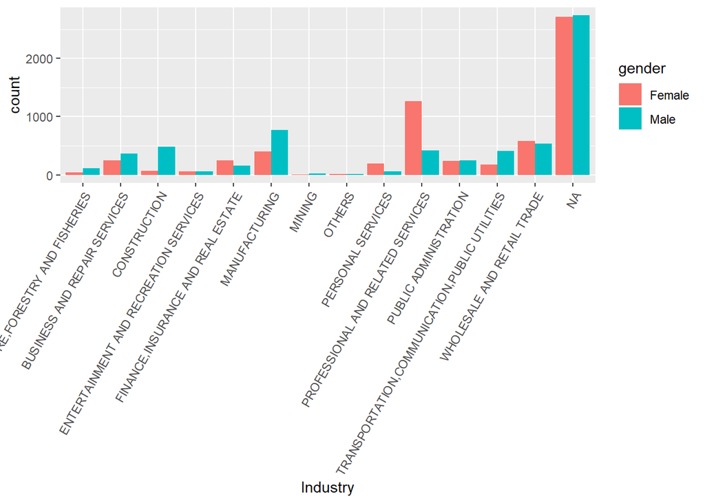

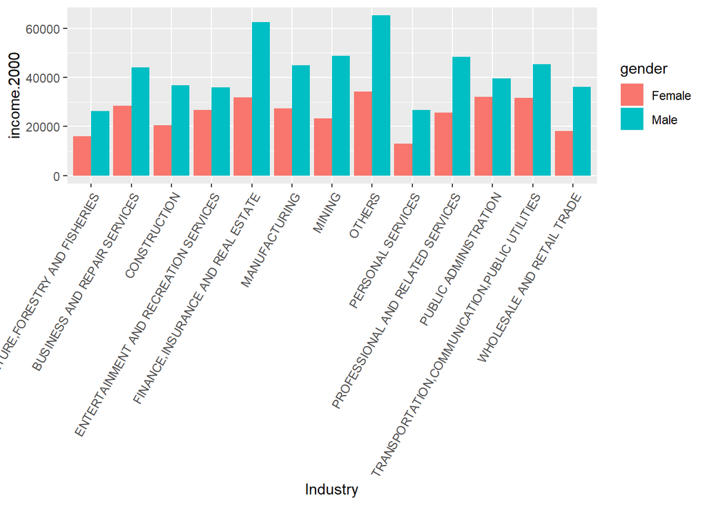

#### 3. Income 2012

The latest income values of 2012 show are analysed on various factors for gender based inequality. But first lets see the gender based gap in income.

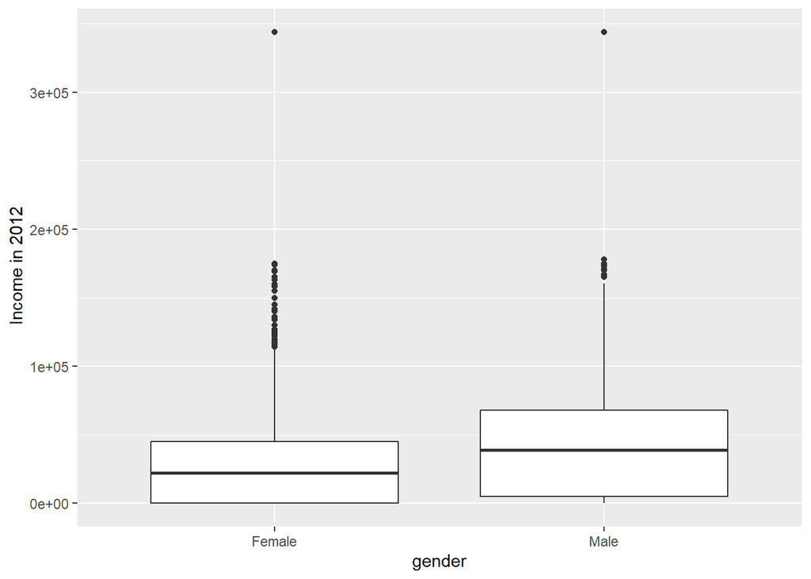

The variables used to highlight gender based income gap are:

##### Family Size

With a larger family size, comes more responsiblities to earn money and support others. Family size should affect income and it can also highlight income gap based on gender.

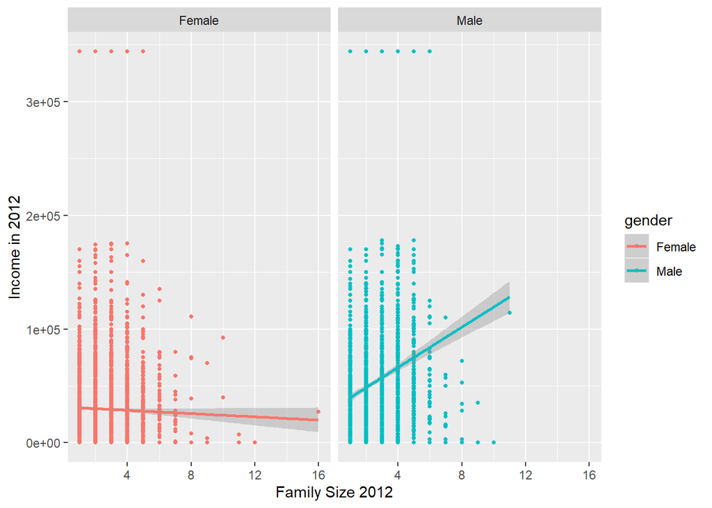

The male income increases greatly with an increase in family size. The female income on the other hand dips slightly with an increase in family size. The male respondent’s family size is also in general smaller than female family size.

##### Alcohol consumption

The number.drink.per.day.2012 variable gives the number of drinks on an average day for the respondents. It can be indicative of alcholic behaviour which will show a dip in income. Alcohlic behaviour can also be gender biased.Let’s have a look at a graph showing this change.

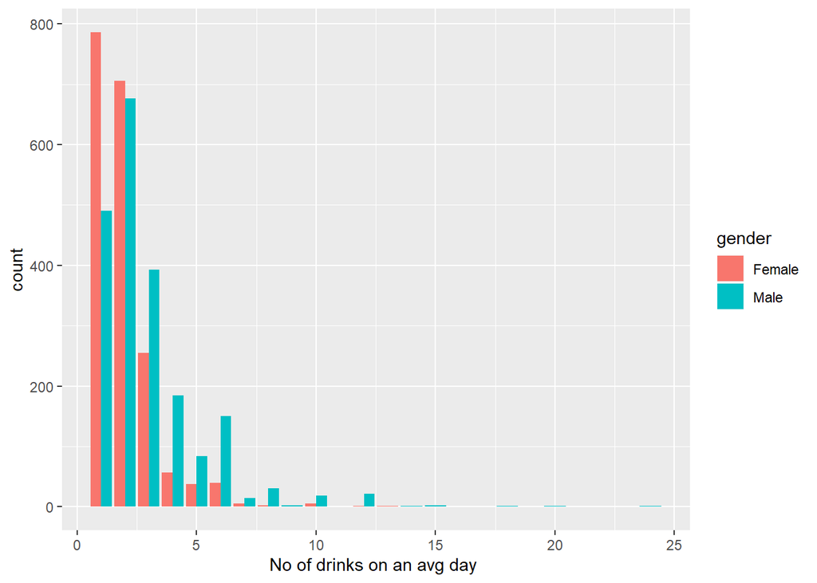

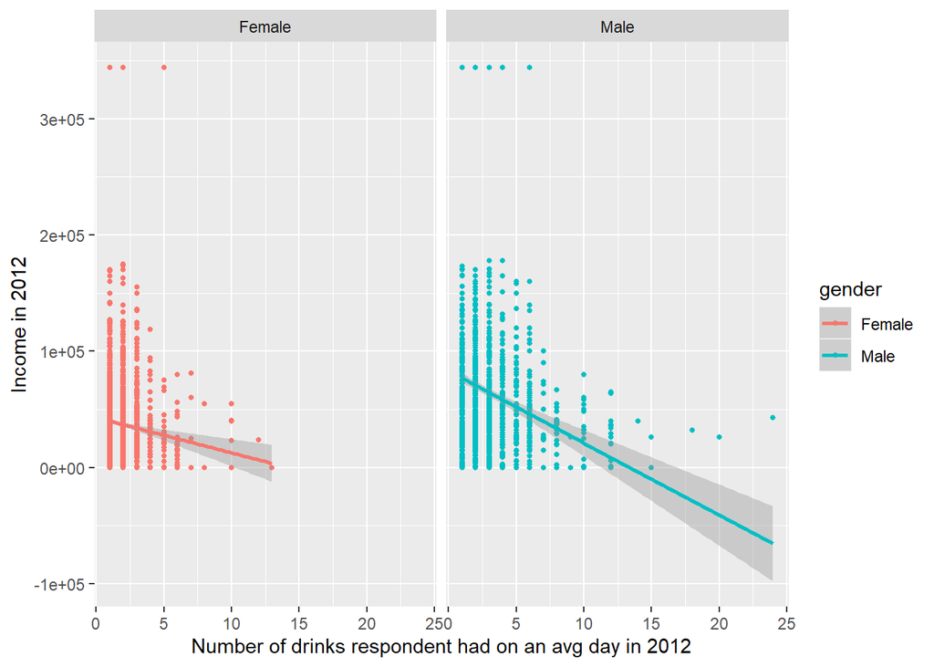

As expected, alcholism affects income significantly. People who have high alcohol consumption tend to earn lesser irrespective of gender. But it affects men much more than women with men being more likely to suffer from alcoholism.

##### Region based Income Mapping

There income for 2012 can be divided based on region as well into 4 different areas: North East, North Central, South and West.  
Income tends to vary across regions so income disparity can also vary a lot.

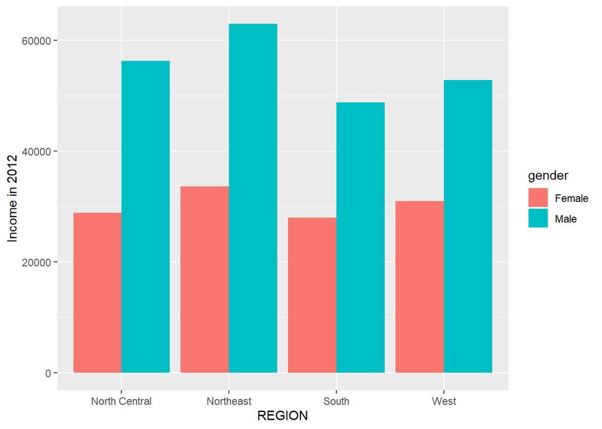

The people from North East region have the highest income of all while the people from South have the lowest income. The income gap differs a lot from region. This is analysed in depth in the Analysis Section.

##### Education Level

Education has a big effect on earning capabilities of an individual. Data regarding the education is available in the highest.education.2012 variable in terms of number of years of education.

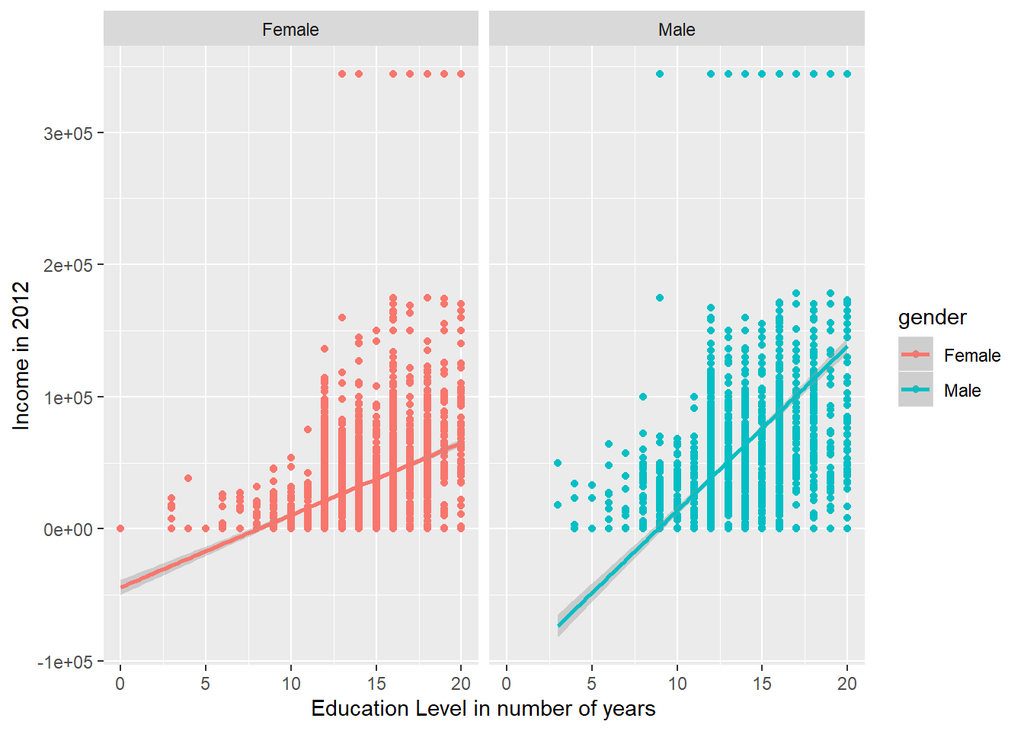

Education increase income significantly for both genders. But the increase is much more prominent for male respondents compared to female ones. This gap is significant enough to be consider gender based bias. It will analysed in detail going ahead.

##### Industry of Employment

As evident in case of the year 2000 income data, industry of employment can affect the income bias a lot. Lets have a look at this disparity for 2012:

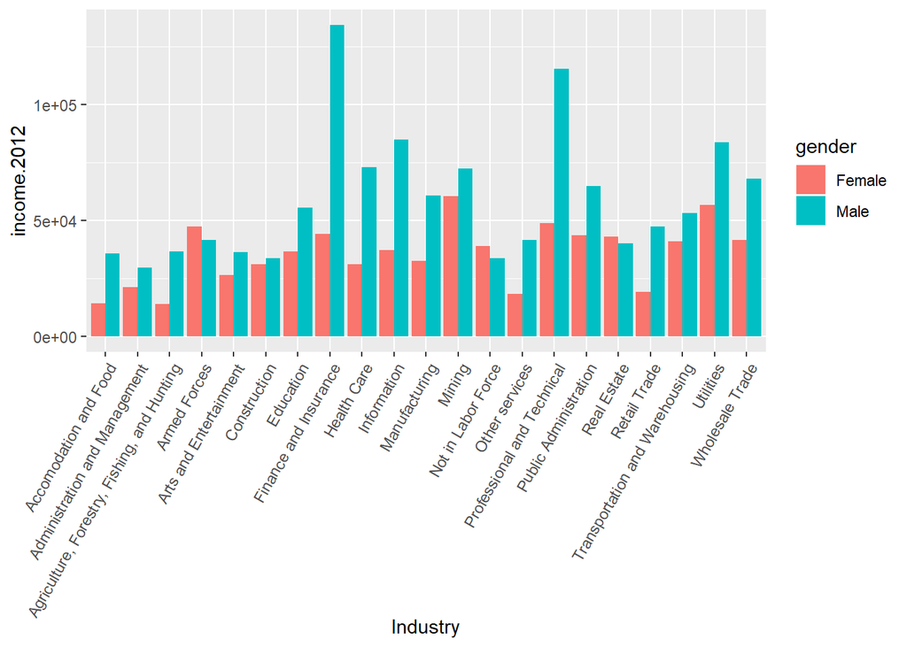